# Introduction

A hierarchical time series is a multivariate time series subject to linear aggregation constraints . Forecasts for such series are considered coherent when lower-level predictions aggregate exactly to higher levels, satisfying the system’s aggregation constraints. In practice, base forecasts are often produced independently at each level, which can lead to incoherence. Forecast reconciliation provides a principled post-processing framework that adjusts these base forecasts to produce aggregate-consistent predictions while retaining as much of the original information as possible . Forecasts may be either point forecasts, representing single most-likely future values, or probabilistic forecasts, representing a distribution over possible future outcomes. A comprehensive review of point and probabilistic reconciliation methods is provided by .

Several R packages on CRAN implement forecast reconciliation across diverse scenarios, including point versus probabilistic forecasts, discrete versus continuous data, and different hierarchical structures (e.g., temporal or cross-sectional). While forecast reconciliation has been studied extensively for discrete and continuous-valued time series, comparatively little attention has been given to hierarchical forecasting under bounded constraints.

One of the most widely used packages for point-forecast reconciliation of hierarchical and grouped time series is . This package implements classical methods such as bottom-up (BU), where bottom-level forecasts are aggregated to form higher-level predictions, and top-down (TD), where parent-level forecasts are disaggregated to child nodes. It also provides more advanced methods, including the Optimal Combination (OC) approach of and the Minimum Trace (MinT) method of . OC uses a regression-based framework to adjust forecasts at the bottom level so that they aggregate coherently, while MinT formulates reconciliation as a constrained optimization problem that minimizes the trace of the reconciled forecast error covariance matrix. The package extends hierarchical reconciliation to the tidyverse ecosystem, providing BU, TD, middle-out (MO), and MinT methods . Both and focus on point forecasts for cross-sectional hierarchies, assuming underlying Gaussian distributions. For more complex or non-standard structures, including temporal hierarchies, offers flexible reconciliation methods with efficient sparse matrix handling, though it also targets point forecasts only .

For probabilistic reconciliation, the works of and have been foundational. The package explicitly frames reconciliation as an optimization problem based on proper scoring rules, generating coherent probabilistic samples by minimizing the Energy Score . However like the aforementioned packages, this method also only considers reconciliation of data generated from Gaussian distributions. Many empirical applications further involve discrete or bounded supports, introducing additional challenges that are not adequately addressed by these standard Gaussian-based reconciliation methods. enforces coherence through conditioning under aggregation constraints. It supports Gaussian data as well as count data, employing Bottom-Up Importance Sampling (BUIS) to produce lower-bounded, aggregate-consistent probabilistic forecasts . However, this package does not deal with fully-bounded distributions like the Beta distribution for the reconciliation of proportions.

To address these challenges, we present the package which generates coherent hierarchical forecasts for bounded continuous and lower-bounded discrete variables. Our contribution lies in providing a method to obtain coherent and accurate forecast densities for both bounded and lower-bounded densities. The approach respects the natural bounds of parent distributions. We demonstrate its performance using simulated Beta and Poisson hierarchical data structures.

# Theory and Methods unpinning

# Using

## The functions of

The package provides pre-defined convolution functions for Poisson, Beta, zero-inflated Beta (ZIB), and zero-one inflated Beta (ZOIB) distributions. These functions can operate on either point estimates or Monte Carlo samples of the bottom-level series. They are parallelised to run efficiently across the full range of evaluation inputs.

- **Point estimate inputs**
  - `Poisson_convolution_density_point_parallel`
  - `Beta_convolution_density_point_parallel`
  - `ZIB_convolution_density_point_parallel`
  - `ZOIB_convolution_density_point_parallel`
- **Sample-based inputs**
  - `Poisson_convolution_density_parallel`
  - `Beta_convolution_density_parallel`
  - `ZIB_convolution_density_parallel`
  - `ZOIB_convolution_density_parallel`

Additionally, the package includes the `tilt_density` function, which exponentially tilts a density toward a specified target mean. This function supports both discrete and continuous distributions, providing a flexible tool for adjusting predictive densities.

## Case 1: Aggregating count forecasts

### The data

[figure not shown]

### Modelling the base forecasts

To obtain base forecasts, we fit standard generalized linear models (GLMs) independently to each node in the hierarchy using `glm()` from the package. These models serve as a simple and reproducible forecasting baseline; our primary contribution lies in the reconciliation methodology applied to the resulting forecasts. For each node, we generate a series of rolling one-step-ahead forecasts. At each step, we record both the in-sample fitted values and the one-step-ahead predictive mean for the rate parameter of each observation. These values are subsequently used to construct a predictive point forecast for each series. These predictions form the base point forecasts that are subsequently reconciled.

### Coherent hierarchical forecasting

We construct a coherent probabilistic forecast for the top-level series by combining bottom-level Poisson forecasts through convolution and subsequently enforcing moment consistency via exponential tilting. As the sum of independent Poisson random variables is also Poisson, we may use a stepwise procedure in which lower-level tilted densities are convolved to form the starting density of their parent node. This ensures that the resulting probability mass function (PMF) respects aggregation constraints while aligning with the predictive means obtained from the base models.

The procedure requires:

- Predictive mean estimates for the top-level series (`A`)
- Predictive mean estimates for the bottom-level series (`AA`, `AB`, `BA`, `BB`)
- A discrete support grid over which the PMFs are evaluated

To begin, we assume the bottom series is given by $b_{m, t} \sim \mathrm{Poisson}(\lambda_{m,t})$ and let the mean of these forecasts be given by $\hat{\lambda}_{m,t}$. Taking advantage of the summation property of Poisson distributed variables, the expected value of the convoluted top series density is given by $\sum_{i=1}^{j}\lambda_{i,t}$. Thus via convolution, the estimated PMF of the top series node is given by,
$$\begin{align}
f_{m+1,t}(u_{t}) &=
\frac{ (\sum_{i=1}^{j}\lambda_{i,t})^{u_{t}}
e^{-(\sum_{i=1}^{j}\lambda_{i,t})}}{u_{t}!},
\qquad u_{t} \in \mathbb{N}_0.
\end{align}$$

For illustration, base forecasts are generated using a rolling Poisson GLM. The implementation is provided in a helper function within the article for reproducibility, but the reconciliation framework is model-agnostic and can be applied to any suitable base forecasts.

```r
library(ggplot2)
library(boundHTS)

# Forecast origin
t <- 50
all_series <- c("Tot","AA", "AB", "BA", "BB")
bottom_series <- c("AA", "AB", "BA", "BB")
top_y_vals <- 0:10  # support for PMF

# Example: one-step-ahead Poisson predictive means
# Fit GLM to bottom-level series
fit_list <- lapply(all_series, function(series) {
  glm(as.formula(paste(series, "~ X + I(X^2)")),
      data = poisson_sim_data[1:(t-1), ],
      family = poisson)
})

# Predictive means at time t
lambda_pred <- sapply(fit_list, function(fit) {
  predict(fit, newdata = poisson_sim_data[t, ])
})

# Convolution density for total-level series
conv_density <- Poisson_convolution_density_point_parallel(z_values = top_y_vals,
                                                           lambda_vector = lambda_pred[-1])

# Construct tilted density to match predictive mean
f_tilted <- tilt_density(mu_theory = lambda_pred[1],
                         y_vals = top_y_vals,
                         f_y = conv_density,
                         discrete = TRUE)

# Prepare data for plotting
df_plot <- data.frame(
  y = rep(top_y_vals, 2),
  pmf = c(f_tilted$f_tilted, conv_density),
  Density = rep(c("Tilted density", "Convoluted density"),
                each = length(top_y_vals))
)
```

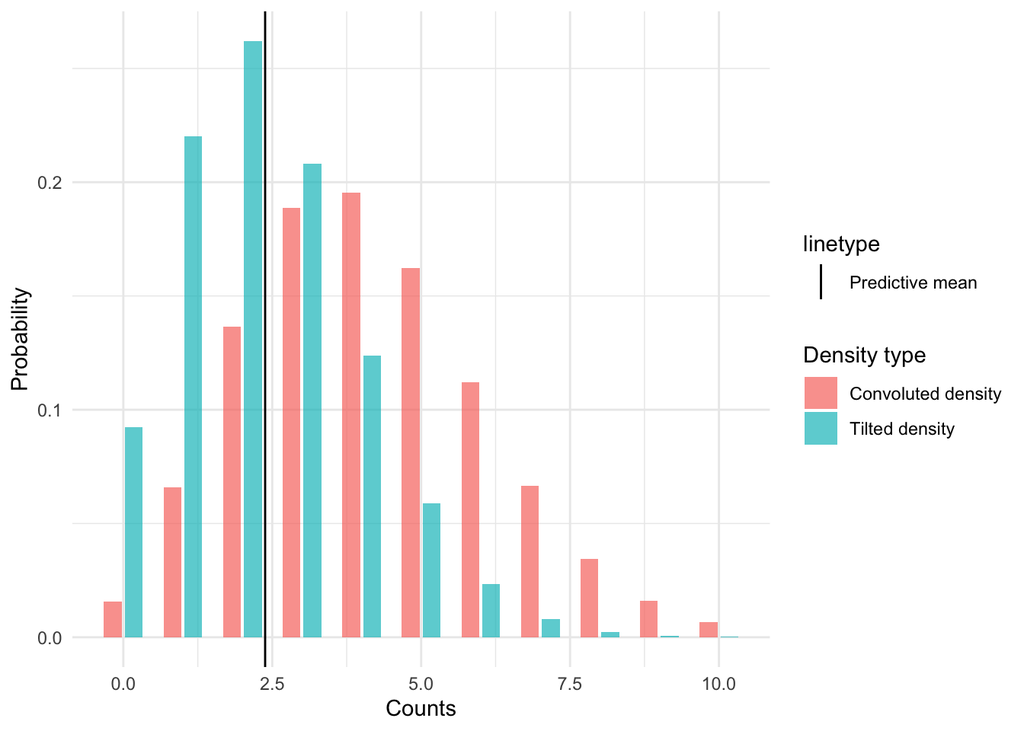

The tilted and convoluted denisties of the top series for a given time point.

## Case 2: Aggregating proportional forecasts

### The data

To begin, we consider a simulated hierarchical Beta dataset with a two-level structure. The hierarchical structure is given by Figure @ref(fig:sim_beta_setup). Due to the compositional nature of the data, the values across nodes are deterministically linked. As a result, only half of the full hierarchical tree must be explicitly simulated, since the remaining nodes can be obtained through deterministic aggregation. The bottom-level series (AA, AB) are constructed from autoregressive latent processes on the logit scale with correlated Gaussian noise terms. A full decription of this data generating process can be found in the Appendix. In this instance, the number of bottom-series is $M=2$ and the number of observation is $N=250$.

[figure not shown]

The two-level hierarchical set up of the Beta simulation. The two child nodes (AA, AB) aggregate to the parent node, A.

### Coherent hierarchical forecasting

Like before, we construct a coherent probabilistic forecast for the top-level series by combining bottom-level weighted Beta forecasts through convolution and subsequently enforcing moment consistency via exponential tilting.

The procedure requires:

- Predictive mean estimates for the top-level series (`A`).
- Predictive mean estimates for the bottom-level series (`AA`, `AB`).
- An fine and evenly spaced grid of support over which the PDFs are approximated.

To begin, we assume the bottom series is given by $b_{m, t} \sim \mathrm{Beta}(\mu_{m,t}*\phi_{m}, (1 - \mu_{m,t})*\phi_{m})$ and let the mean of these forecasts be given by $\hat{\mu}_{m,t}$ which is bounded by [0,1].

Conditional on $b_{m,t}$, the density of the aggregated top series proportion, $u_{A,t}$, is then approximated via convolutions. A closed form solution for the convolution of Beta distributions does not exist, as such it is necessary to estimate the integral via Monte-Carlo integration. Specifically, the density of $u_{A,t}$ is defined as,
$$\begin{align}
f_{A,t}(u_{A,t})
&= \int \dots \int
\bigg( \prod_{i=1}^{m-1} f_{i,t}(b_{i,t}) \bigg )
f_{m,t}( u_{m',t} - \sum_{i=1}^{m-1} b_{i,t}) \, db.
\end{align}$$

```r
fit_list <- lapply(all_series, function(s) {
  forecast::auto.arima(beta_sim_data[1:(t_idx-1), paste0("logit_", s)])
})
```

```r
mu_pred <- sapply(fit_list, predict, h=1)
mu_pred <- as.vector(unlist(mu_pred[1,]))

sim_pred <- lapply(fit_list, function(fit) {
  replicate(5000, simulate(fit, nsim=1, future=TRUE)[[1]])
})

var_pred <- sapply(sim_pred, function(x) var(x))
phi_pred <- (1/var_pred)-1

# Calculate the beta distribution parameters
alpha <- mu_pred * phi_pred
beta  <- (1-mu_pred) * phi_pred
```

```r
weighted_samps <- array(NA, dim=c(100,100,length(bottom_series)))

for(b in seq_along(bottom_series)) {
  weighted_samps[,,b] <- matrix(ExtDist::rBeta_ab(100*100,
                                    alpha[b+1], beta[b+1], a=0, b=weights_bottom[b]),
                                100, 100)
}

conv_density <- Beta_convolution_density_point_parallel(
  z_values=top_y_vals, alpha_point=alpha[2:3], beta_point=beta[2:3],
  weighted_samps=weighted_samps, weights=weights_bottom)

f_tilted <- tilt_density(mu_pred[1], top_y_vals, conv_density, discrete=FALSE)
```

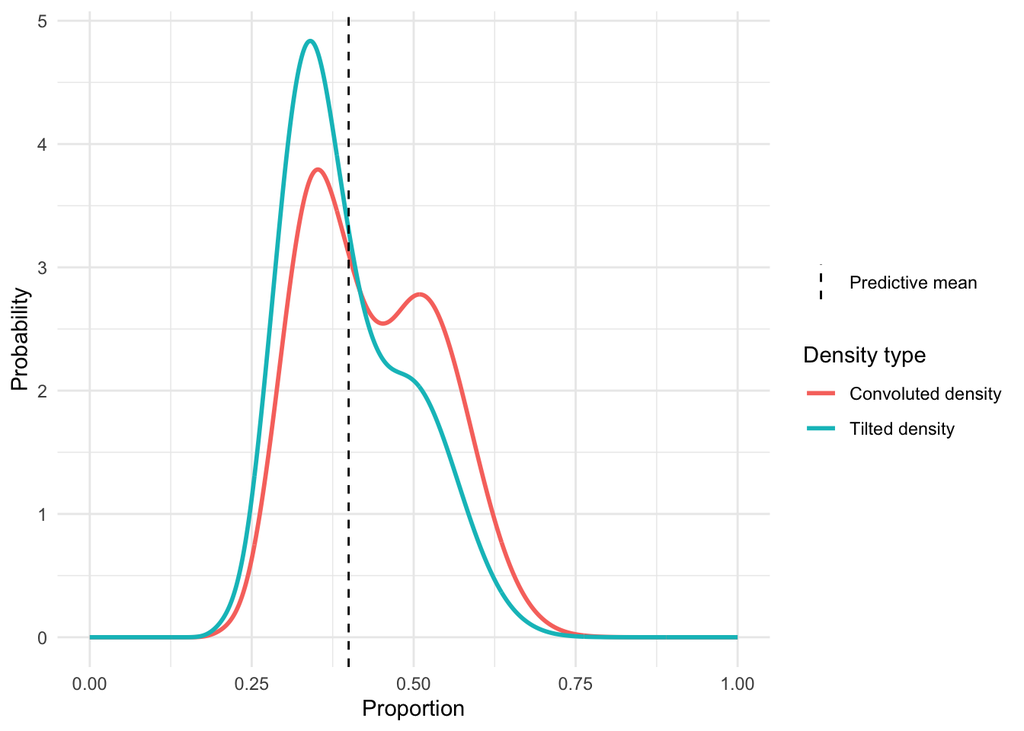

The tilted and convoluted denisties of the top series for a given time point.

# Appendix

## Data generating process for Case 1: Hierarchical Poisson distributions.

The bottom-level series are constructed using a generalized linear model with a quadratic log-link. For each bottom series $m=1,\dots,M$, regression coefficients are drawn independently from a uniform distribution,
$$\begin{align*}
(\theta_{0,m}, \theta_{1,m}, \theta_{2,m}) \sim
\text{Uniform}(0.4,\,0.5).
\end{align*}$$
A common covariate $x_{t}$ is drawn for each observation $t=1,\dots,N$ from a uniform distribution on $[0,1]$,
$$\begin{align*}
x_{t} \sim \text{Uniform}(0, 1).
\end{align*}$$
The Poisson rate parameter is then defined as
$$\begin{align*}
\lambda_{m,t} &= \exp\!\big( \theta_{0,m} + \theta_{1,m}x_t +
\theta_{2,m} x_t^2 \big),
\end{align*}$$
with observed bottom series counts generated according to
$$\begin{align*}
b_{m,t} &\sim \text{Poisson}(\lambda_{m,t}).
\end{align*}$$
where, $b_{m,t}$ is the count of bottom series $m$ at time $t$. \ To introduce additional variability, integer-valued shocks $\varepsilon_{m,t} \in \{-1,0,1\}$ are added independently to each $b_{m,t}$. The distribution of $\varepsilon_{i,m}$ is series-specific to ensure that noise does not systematically cancel out when aggregating across series:
$$\begin{align*}
\begin{aligned}
\varepsilon_{1,t} &\sim \{-1,0,1\} \;\; \text{with probabilities }
(0.3,0.4,0.3), \\
\varepsilon_{2,t} &\sim \{-1,0,1\} \;\; \text{with probabilities }
(0.5,0.4,0.1), \\
\varepsilon_{3,} &\sim \{-1,0,1\} \;\; \text{with probabilities }
(0.33,0.33,0.34), \\
\varepsilon_{4,t} &\sim \{-1,0,1\} \;\; \text{with probabilities }
(0.2,0.3,0.5).
\end{aligned}
\end{align*}$$
To ensuring non-negativity, the perturbed bottom-level series are then given by
$$\begin{align*}
b^{*}_{m,t} = \max\!\big(0,\, b_{m,t} + \varepsilon_{m,t}\big).
\end{align*}$$
At the aggregate level, the series is obtained by summing across the unperturbed bottom-level counts:
$$\begin{align*}
u_{t} = \sum_{m=1}^M b_{m,t}.
\end{align*}$$
where, $u_{t}$ is the count of top-level series at time $t$. \

The final noisy dataset consists of 2000 draws of the covariate $x$, the aggregate top series $u_{t}$, and the four perturbed bottom-level series $(b^{\ast}_{1},\dots,b^{\ast}_{4})$.

## Data generating process for Case 2: Hierarchical Beta distributions.

The bottom-level series $(b_{AA, t}, b_{AB, t})$ are constructed from autoregressive latent processes on the logit scale with correlated Gaussian noise terms. Specifically, for $m = \{AA,AB\}$, $t = 1,\dots,N^\star$ where $N^\star = 400$ and burn-in $T_0 = 150$, we define
$$\begin{equation}
\begin{aligned}
\text{logit}(b_{m,1}) &\sim \text{Normal}(0,1),\\
\text{logit}(b_{m,t}) &= \beta_{0,m} + \beta_{1,m}\,b_{m,t-1} +
\epsilon_{m, t}, \\
\end{aligned}
\end{equation}$$
where, $b_{m, t}$ is the proportion of bottom-level series $m$ at time $t$. \